# Billboard_data

```python
import pandas as pd
import seaborn as sns
import matplotlib.pyplot as plt

import requests
import io

url="https://raw.githubusercontent.com/hadley/tidy-data/master/data/billboard.csv"
content_string = requests.get(url).content
billboard = pd.read_csv(io.StringIO(content_string.decode("ISO-8859-1"))).iloc[:, 0:]
#billboard = pd.read_csv("https://raw.githubusercontent.com/hadley/tidy-data/master/data/billboard.csv", encoding="ISO-8859-1") # <-- I literally copied the "encoding" part from stackoverflow

billboard
```

|  | year | artist.inverted | track | time | genre | date.entered | date.peaked | x1st.week | x2nd.week | x3rd.week | ... | x67th.week | x68th.week | x69th.week | x70th.week | x71st.week | x72nd.week | x73rd.week | x74th.week | x75th.week | x76th.week |
| --- | --- | --- | --- | --- | --- | --- | --- | --- | --- | --- | --- | --- | --- | --- | --- | --- | --- | --- | --- | --- | --- |
| 0 | 2000 | Destiny's Child | Independent Women Part I | 3:38 | Rock | 2000-09-23 | 2000-11-18 | 78 | 63.0 | 49.0 | ... | NaN | NaN | NaN | NaN | NaN | NaN | NaN | NaN | NaN | NaN |
| 1 | 2000 | Santana | Maria, Maria | 4:18 | Rock | 2000-02-12 | 2000-04-08 | 15 | 8.0 | 6.0 | ... | NaN | NaN | NaN | NaN | NaN | NaN | NaN | NaN | NaN | NaN |
| 2 | 2000 | Savage Garden | I Knew I Loved You | 4:07 | Rock | 1999-10-23 | 2000-01-29 | 71 | 48.0 | 43.0 | ... | NaN | NaN | NaN | NaN | NaN | NaN | NaN | NaN | NaN | NaN |
| 3 | 2000 | Madonna | Music | 3:45 | Rock | 2000-08-12 | 2000-09-16 | 41 | 23.0 | 18.0 | ... | NaN | NaN | NaN | NaN | NaN | NaN | NaN | NaN | NaN | NaN |
| 4 | 2000 | Aguilera, Christina | Come On Over Baby (All I Want Is You) | 3:38 | Rock | 2000-08-05 | 2000-10-14 | 57 | 47.0 | 45.0 | ... | NaN | NaN | NaN | NaN | NaN | NaN | NaN | NaN | NaN | NaN |
| 5 | 2000 | Janet | Doesn't Really Matter | 4:17 | Rock | 2000-06-17 | 2000-08-26 | 59 | 52.0 | 43.0 | ... | NaN | NaN | NaN | NaN | NaN | NaN | NaN | NaN | NaN | NaN |
| 6 | 2000 | Destiny's Child | Say My Name | 4:31 | Rock | 1999-12-25 | 2000-03-18 | 83 | 83.0 | 44.0 | ... | NaN | NaN | NaN | NaN | NaN | NaN | NaN | NaN | NaN | NaN |
| 7 | 2000 | Iglesias, Enrique | Be With You | 3:36 | Latin | 2000-04-01 | 2000-06-24 | 63 | 45.0 | 34.0 | ... | NaN | NaN | NaN | NaN | NaN | NaN | NaN | NaN | NaN | NaN |
| 8 | 2000 | Sisqo | Incomplete | 3:52 | Rock | 2000-06-24 | 2000-08-12 | 77 | 66.0 | 61.0 | ... | NaN | NaN | NaN | NaN | NaN | NaN | NaN | NaN | NaN | NaN |
| 9 | 2000 | Lonestar | Amazed | 4:25 | Country | 1999-06-05 | 2000-03-04 | 81 | 54.0 | 44.0 | ... | NaN | NaN | NaN | NaN | NaN | NaN | NaN | NaN | NaN | NaN |
| 10 | 2000 | N'Sync | It's Gonna Be Me | 3:10 | Rock | 2000-05-06 | 2000-07-29 | 82 | 70.0 | 51.0 | ... | NaN | NaN | NaN | NaN | NaN | NaN | NaN | NaN | NaN | NaN |
| 11 | 2000 | Aguilera, Christina | What A Girl Wants | 3:18 | Rock | 1999-11-27 | 2000-01-15 | 71 | 51.0 | 28.0 | ... | NaN | NaN | NaN | NaN | NaN | NaN | NaN | NaN | NaN | NaN |
| 12 | 2000 | Vertical Horizon | Everything You Want | 4:01 | Rock | 2000-01-22 | 2000-07-15 | 70 | 61.0 | 53.0 | ... | NaN | NaN | NaN | NaN | NaN | NaN | NaN | NaN | NaN | NaN |
| 13 | 2000 | Creed | With Arms Wide Open | 3:52 | Rock | 2000-05-13 | 2000-11-11 | 84 | 78.0 | 76.0 | ... | NaN | NaN | NaN | NaN | NaN | NaN | NaN | NaN | NaN | NaN |
| 14 | 2000 | Aaliyah | Try Again | 4:03 | Rock | 2000-03-18 | 2000-06-17 | 59 | 53.0 | 38.0 | ... | NaN | NaN | NaN | NaN | NaN | NaN | NaN | NaN | NaN | NaN |
| 15 | 2000 | matchbox twenty | Bent | 4:12 | Rock | 2000-04-29 | 2000-07-22 | 60 | 37.0 | 29.0 | ... | NaN | NaN | NaN | NaN | NaN | NaN | NaN | NaN | NaN | NaN |
| 16 | 2000 | Carey, Mariah | Thank God I Found You | 4:14 | Rock | 1999-12-11 | 2000-02-19 | 82 | 68.0 | 50.0 | ... | NaN | NaN | NaN | NaN | NaN | NaN | NaN | NaN | NaN | NaN |
| 17 | 2000 | Hill, Faith | Breathe | 4:04 | Rap | 1999-11-06 | 2000-04-22 | 81 | 68.0 | 62.0 | ... | NaN | NaN | NaN | NaN | NaN | NaN | NaN | NaN | NaN | NaN |
| 18 | 2000 | Mya | Case Of The Ex (Whatcha Gonna Do) | 3:50 | Rock | 2000-08-19 | 2000-12-02 | 72 | 57.0 | 52.0 | ... | NaN | NaN | NaN | NaN | NaN | NaN | NaN | NaN | NaN | NaN |
| 19 | 2000 | Dream | He Loves U Not | 3:43 | Rock | 2000-09-30 | 2000-12-30 | 99 | 92.0 | 81.0 | ... | NaN | NaN | NaN | NaN | NaN | NaN | NaN | NaN | NaN | NaN |
| 20 | 2000 | Braxton, Toni | He Wasn't Man Enough | 4:21 | Rock | 2000-03-18 | 2000-05-06 | 63 | 55.0 | 48.0 | ... | NaN | NaN | NaN | NaN | NaN | NaN | NaN | NaN | NaN | NaN |
| 21 | 2000 | Anthony, Marc | You Sang To Me | 3:50 | Latin | 2000-02-26 | 2000-06-03 | 77 | 54.0 | 50.0 | ... | NaN | NaN | NaN | NaN | NaN | NaN | NaN | NaN | NaN | NaN |
| 22 | 2000 | 98¡ | Give Me Just One Night (Una Noche) | 3:24 | Rock | 2000-08-19 | 2000-09-30 | 51 | 39.0 | 34.0 | ... | NaN | NaN | NaN | NaN | NaN | NaN | NaN | NaN | NaN | NaN |
| 23 | 2000 | Destiny's Child | Jumpin' Jumpin' | 3:48 | Rock | 2000-05-13 | 2000-08-19 | 74 | 71.0 | 65.0 | ... | NaN | NaN | NaN | NaN | NaN | NaN | NaN | NaN | NaN | NaN |
| 24 | 2000 | 3 Doors Down | Kryptonite | 3:53 | Rock | 2000-04-08 | 2000-11-11 | 81 | 70.0 | 68.0 | ... | NaN | NaN | NaN | NaN | NaN | NaN | NaN | NaN | NaN | NaN |
| 25 | 2000 | Sisqo | Thong Song | 4:05 | Rock | 2000-01-29 | 2000-05-20 | 74 | 63.0 | 35.0 | ... | NaN | NaN | NaN | NaN | NaN | NaN | NaN | NaN | NaN | NaN |
| 26 | 2000 | Aguilera, Christina | I Turn To You | 4:00 | Rock | 2000-04-15 | 2000-07-01 | 50 | 39.0 | 30.0 | ... | NaN | NaN | NaN | NaN | NaN | NaN | NaN | NaN | NaN | NaN |
| 27 | 2000 | Houston, Whitney | My Love Is Your Love | 4:16 | Rock | 1999-09-04 | 2000-01-08 | 81 | 68.0 | 44.0 | ... | NaN | NaN | NaN | NaN | NaN | NaN | NaN | NaN | NaN | NaN |
| 28 | 2000 | Joe | I Wanna Know | 4:57 | Rock | 2000-01-01 | 2000-07-01 | 94 | 86.0 | 69.0 | ... | NaN | NaN | NaN | NaN | NaN | NaN | NaN | NaN | NaN | NaN |
| 29 | 2000 | Jordan, Montell | Get It On.. Tonite | 4:34 | Rap | 1999-10-23 | 2000-02-12 | 92 | 80.0 | 72.0 | ... | NaN | NaN | NaN | NaN | NaN | NaN | NaN | NaN | NaN | NaN |
| ... | ... | ... | ... | ... | ... | ... | ... | ... | ... | ... | ... | ... | ... | ... | ... | ... | ... | ... | ... | ... | ... |
| 287 | 2000 | 2Ge+her | The Hardest Part Of Breaking Up (Is Getting Ba... | 3:15 | R&B | 2000-09-02 | 2000-09-09 | 91 | 87.0 | 92.0 | ... | NaN | NaN | NaN | NaN | NaN | NaN | NaN | NaN | NaN | NaN |
| 288 | 2000 | Madison Avenue | Don't Call Me Baby | 3:44 | Electronica | 2000-07-08 | 2000-09-16 | 98 | 96.0 | 93.0 | ... | NaN | NaN | NaN | NaN | NaN | NaN | NaN | NaN | NaN | NaN |
| 289 | 2000 | Eve | Got It All | 3:48 | Rap | 2000-07-15 | 2000-07-22 | 89 | 88.0 | 88.0 | ... | NaN | NaN | NaN | NaN | NaN | NaN | NaN | NaN | NaN | NaN |
| 290 | 2000 | Limp Bizkit | Re-Arranged | 4:08 | Rock | 1999-12-04 | 2000-02-05 | 91 | 91.0 | 90.0 | ... | NaN | NaN | NaN | NaN | NaN | NaN | NaN | NaN | NaN | NaN |
| 291 | 2000 | Spencer, Tracie | Still In My Heart | 4:11 | Rock | 2000-03-04 | 2000-03-11 | 95 | 88.0 | 98.0 | ... | NaN | NaN | NaN | NaN | NaN | NaN | NaN | NaN | NaN | NaN |
| 292 | 2000 | Nu Flavor | 3 Little Words | 3:54 | R&B | 2000-06-03 | 2000-06-17 | 97 | 97.0 | 89.0 | ... | NaN | NaN | NaN | NaN | NaN | NaN | NaN | NaN | NaN | NaN |
| 293 | 2000 | Tamar | If You Don't Wanna Love Me | 4:02 | Rock | 2000-03-25 | 2000-04-15 | 98 | 98.0 | 92.0 | ... | NaN | NaN | NaN | NaN | NaN | NaN | NaN | NaN | NaN | NaN |
| 294 | 2000 | Levert, Gerald | Baby U Are | 4:10 | R&B | 2000-08-19 | 2000-08-26 | 96 | 89.0 | 92.0 | ... | NaN | NaN | NaN | NaN | NaN | NaN | NaN | NaN | NaN | NaN |
| 295 | 2000 | Hart, Beth | L.A. Song | 3:47 | Country | 1999-11-27 | 2000-01-15 | 99 | 100.0 | 98.0 | ... | NaN | NaN | NaN | NaN | NaN | NaN | NaN | NaN | NaN | NaN |
| 296 | 2000 | Diffie, Joe | The Quittin' Kind | 3:23 | Country | 2000-01-01 | 2000-01-22 | 98 | 100.0 | 100.0 | ... | NaN | NaN | NaN | NaN | NaN | NaN | NaN | NaN | NaN | NaN |
| 297 | 2000 | Funkmaster Flex | Do You | 4:14 | Rap | 2000-11-11 | 2000-12-02 | 92 | 92.0 | 95.0 | ... | NaN | NaN | NaN | NaN | NaN | NaN | NaN | NaN | NaN | NaN |
| 298 | 2000 | Price, Kelly | Love Sets You Free | 3:46 | Rock | 2000-05-13 | 2000-05-20 | 92 | 91.0 | 98.0 | ... | NaN | NaN | NaN | NaN | NaN | NaN | NaN | NaN | NaN | NaN |
| 299 | 2000 | En Vogue | Riddle | 5:10 | Rock | 2000-06-17 | 2000-06-17 | 92 | 92.0 | 97.0 | ... | NaN | NaN | NaN | NaN | NaN | NaN | NaN | NaN | NaN | NaN |
| 300 | 2000 | Herndon, Ty | No Mercy | 4:43 | Country | 2000-03-18 | 2000-05-06 | 100 | 99.0 | 99.0 | ... | NaN | NaN | NaN | NaN | NaN | NaN | NaN | NaN | NaN | NaN |
| 301 | 2000 | Anastacia | I'm Outta Love | 4:01 | Pop | 2000-04-01 | 2000-04-01 | 92 | NaN | NaN | ... | NaN | NaN | NaN | NaN | NaN | NaN | NaN | NaN | NaN | NaN |
| 302 | 2000 | Trina | Pull Over | 2:58 | Rap | 2000-09-09 | 2000-09-16 | 97 | 93.0 | 96.0 | ... | NaN | NaN | NaN | NaN | NaN | NaN | NaN | NaN | NaN | NaN |
| 303 | 2000 | Lil' Mo | Ta Da | 4:17 | Rap | 2000-08-12 | 2000-09-16 | 100 | 99.0 | 97.0 | ... | NaN | NaN | NaN | NaN | NaN | NaN | NaN | NaN | NaN | NaN |
| 304 | 2000 | A*Teens | Dancing Queen | 3:44 | Pop | 2000-07-08 | 2000-07-29 | 97 | 97.0 | 96.0 | ... | NaN | NaN | NaN | NaN | NaN | NaN | NaN | NaN | NaN | NaN |
| 305 | 2000 | Sheist, Shade | Where I Wanna Be | 4:16 | Rap | 2000-11-11 | 2000-11-18 | 96 | 95.0 | 99.0 | ... | NaN | NaN | NaN | NaN | NaN | NaN | NaN | NaN | NaN | NaN |
| 306 | 2000 | De La Soul | All Good? | 5:02 | Rap | 2000-12-23 | 2000-12-23 | 96 | 96.0 | 100.0 | ... | NaN | NaN | NaN | NaN | NaN | NaN | NaN | NaN | NaN | NaN |
| 307 | 2000 | Larrieux, Amel | Get Up | 4:02 | R&B | 2000-03-04 | 2000-03-11 | 100 | 97.0 | 97.0 | ... | NaN | NaN | NaN | NaN | NaN | NaN | NaN | NaN | NaN | NaN |
| 308 | 2000 | Braxton, Toni | Spanish Guitar | 4:24 | Rock | 2000-12-02 | 2000-12-02 | 98 | 98.0 | 98.0 | ... | NaN | NaN | NaN | NaN | NaN | NaN | NaN | NaN | NaN | NaN |
| 309 | 2000 | Tuesday | I Know | 4:06 | Rock | 2000-12-30 | 2000-12-30 | 98 | 98.0 | NaN | ... | NaN | NaN | NaN | NaN | NaN | NaN | NaN | NaN | NaN | NaN |
| 310 | 2000 | LL Cool J | Imagine That | 4:00 | Rap | 2000-08-12 | 2000-08-19 | 99 | 98.0 | NaN | ... | NaN | NaN | NaN | NaN | NaN | NaN | NaN | NaN | NaN | NaN |
| 311 | 2000 | Master P | Souljas | 3:33 | Rap | 2000-11-18 | 2000-11-18 | 98 | NaN | NaN | ... | NaN | NaN | NaN | NaN | NaN | NaN | NaN | NaN | NaN | NaN |
| 312 | 2000 | Ghostface Killah | Cherchez LaGhost | 3:04 | R&B | 2000-08-05 | 2000-08-05 | 98 | NaN | NaN | ... | NaN | NaN | NaN | NaN | NaN | NaN | NaN | NaN | NaN | NaN |
| 313 | 2000 | Smith, Will | Freakin' It | 3:58 | Rap | 2000-02-12 | 2000-02-12 | 99 | 99.0 | 99.0 | ... | NaN | NaN | NaN | NaN | NaN | NaN | NaN | NaN | NaN | NaN |
| 314 | 2000 | Zombie Nation | Kernkraft 400 | 3:30 | Rock | 2000-09-02 | 2000-09-02 | 99 | 99.0 | NaN | ... | NaN | NaN | NaN | NaN | NaN | NaN | NaN | NaN | NaN | NaN |
| 315 | 2000 | Eastsidaz, The | Got Beef | 3:58 | Rap | 2000-07-01 | 2000-07-01 | 99 | 99.0 | NaN | ... | NaN | NaN | NaN | NaN | NaN | NaN | NaN | NaN | NaN | NaN |
| 316 | 2000 | Fragma | Toca's Miracle | 3:22 | R&B | 2000-10-28 | 2000-10-28 | 99 | NaN | NaN | ... | NaN | NaN | NaN | NaN | NaN | NaN | NaN | NaN | NaN | NaN |

317 rows × 83 columns

Right now, weeks are stored as different variables, and the individual songs are observations. Let's instead consider the song's appearance each week as a separate observation. This takes the week_number from being an implicit to an explicit variable.

```python
billboard = pd.melt(
    billboard,
    id_vars=billboard.columns[:7],
    var_name="week",
    value_name="rank"
  )
billboard
```

|  | year | artist.inverted | track | time | genre | date.entered | date.peaked | week | rank |
| --- | --- | --- | --- | --- | --- | --- | --- | --- | --- |
| 0 | 2000 | Destiny's Child | Independent Women Part I | 3:38 | Rock | 2000-09-23 | 2000-11-18 | x1st.week | 78.0 |
| 1 | 2000 | Santana | Maria, Maria | 4:18 | Rock | 2000-02-12 | 2000-04-08 | x1st.week | 15.0 |
| 2 | 2000 | Savage Garden | I Knew I Loved You | 4:07 | Rock | 1999-10-23 | 2000-01-29 | x1st.week | 71.0 |
| 3 | 2000 | Madonna | Music | 3:45 | Rock | 2000-08-12 | 2000-09-16 | x1st.week | 41.0 |
| 4 | 2000 | Aguilera, Christina | Come On Over Baby (All I Want Is You) | 3:38 | Rock | 2000-08-05 | 2000-10-14 | x1st.week | 57.0 |
| 5 | 2000 | Janet | Doesn't Really Matter | 4:17 | Rock | 2000-06-17 | 2000-08-26 | x1st.week | 59.0 |
| 6 | 2000 | Destiny's Child | Say My Name | 4:31 | Rock | 1999-12-25 | 2000-03-18 | x1st.week | 83.0 |
| 7 | 2000 | Iglesias, Enrique | Be With You | 3:36 | Latin | 2000-04-01 | 2000-06-24 | x1st.week | 63.0 |
| 8 | 2000 | Sisqo | Incomplete | 3:52 | Rock | 2000-06-24 | 2000-08-12 | x1st.week | 77.0 |
| 9 | 2000 | Lonestar | Amazed | 4:25 | Country | 1999-06-05 | 2000-03-04 | x1st.week | 81.0 |
| 10 | 2000 | N'Sync | It's Gonna Be Me | 3:10 | Rock | 2000-05-06 | 2000-07-29 | x1st.week | 82.0 |
| 11 | 2000 | Aguilera, Christina | What A Girl Wants | 3:18 | Rock | 1999-11-27 | 2000-01-15 | x1st.week | 71.0 |
| 12 | 2000 | Vertical Horizon | Everything You Want | 4:01 | Rock | 2000-01-22 | 2000-07-15 | x1st.week | 70.0 |
| 13 | 2000 | Creed | With Arms Wide Open | 3:52 | Rock | 2000-05-13 | 2000-11-11 | x1st.week | 84.0 |
| 14 | 2000 | Aaliyah | Try Again | 4:03 | Rock | 2000-03-18 | 2000-06-17 | x1st.week | 59.0 |
| 15 | 2000 | matchbox twenty | Bent | 4:12 | Rock | 2000-04-29 | 2000-07-22 | x1st.week | 60.0 |
| 16 | 2000 | Carey, Mariah | Thank God I Found You | 4:14 | Rock | 1999-12-11 | 2000-02-19 | x1st.week | 82.0 |
| 17 | 2000 | Hill, Faith | Breathe | 4:04 | Rap | 1999-11-06 | 2000-04-22 | x1st.week | 81.0 |
| 18 | 2000 | Mya | Case Of The Ex (Whatcha Gonna Do) | 3:50 | Rock | 2000-08-19 | 2000-12-02 | x1st.week | 72.0 |
| 19 | 2000 | Dream | He Loves U Not | 3:43 | Rock | 2000-09-30 | 2000-12-30 | x1st.week | 99.0 |
| 20 | 2000 | Braxton, Toni | He Wasn't Man Enough | 4:21 | Rock | 2000-03-18 | 2000-05-06 | x1st.week | 63.0 |
| 21 | 2000 | Anthony, Marc | You Sang To Me | 3:50 | Latin | 2000-02-26 | 2000-06-03 | x1st.week | 77.0 |
| 22 | 2000 | 98¡ | Give Me Just One Night (Una Noche) | 3:24 | Rock | 2000-08-19 | 2000-09-30 | x1st.week | 51.0 |
| 23 | 2000 | Destiny's Child | Jumpin' Jumpin' | 3:48 | Rock | 2000-05-13 | 2000-08-19 | x1st.week | 74.0 |
| 24 | 2000 | 3 Doors Down | Kryptonite | 3:53 | Rock | 2000-04-08 | 2000-11-11 | x1st.week | 81.0 |
| 25 | 2000 | Sisqo | Thong Song | 4:05 | Rock | 2000-01-29 | 2000-05-20 | x1st.week | 74.0 |
| 26 | 2000 | Aguilera, Christina | I Turn To You | 4:00 | Rock | 2000-04-15 | 2000-07-01 | x1st.week | 50.0 |
| 27 | 2000 | Houston, Whitney | My Love Is Your Love | 4:16 | Rock | 1999-09-04 | 2000-01-08 | x1st.week | 81.0 |
| 28 | 2000 | Joe | I Wanna Know | 4:57 | Rock | 2000-01-01 | 2000-07-01 | x1st.week | 94.0 |
| 29 | 2000 | Jordan, Montell | Get It On.. Tonite | 4:34 | Rap | 1999-10-23 | 2000-02-12 | x1st.week | 92.0 |
| ... | ... | ... | ... | ... | ... | ... | ... | ... | ... |
| 24062 | 2000 | 2Ge+her | The Hardest Part Of Breaking Up (Is Getting Ba... | 3:15 | R&B | 2000-09-02 | 2000-09-09 | x76th.week | NaN |
| 24063 | 2000 | Madison Avenue | Don't Call Me Baby | 3:44 | Electronica | 2000-07-08 | 2000-09-16 | x76th.week | NaN |
| 24064 | 2000 | Eve | Got It All | 3:48 | Rap | 2000-07-15 | 2000-07-22 | x76th.week | NaN |
| 24065 | 2000 | Limp Bizkit | Re-Arranged | 4:08 | Rock | 1999-12-04 | 2000-02-05 | x76th.week | NaN |
| 24066 | 2000 | Spencer, Tracie | Still In My Heart | 4:11 | Rock | 2000-03-04 | 2000-03-11 | x76th.week | NaN |
| 24067 | 2000 | Nu Flavor | 3 Little Words | 3:54 | R&B | 2000-06-03 | 2000-06-17 | x76th.week | NaN |
| 24068 | 2000 | Tamar | If You Don't Wanna Love Me | 4:02 | Rock | 2000-03-25 | 2000-04-15 | x76th.week | NaN |
| 24069 | 2000 | Levert, Gerald | Baby U Are | 4:10 | R&B | 2000-08-19 | 2000-08-26 | x76th.week | NaN |
| 24070 | 2000 | Hart, Beth | L.A. Song | 3:47 | Country | 1999-11-27 | 2000-01-15 | x76th.week | NaN |
| 24071 | 2000 | Diffie, Joe | The Quittin' Kind | 3:23 | Country | 2000-01-01 | 2000-01-22 | x76th.week | NaN |
| 24072 | 2000 | Funkmaster Flex | Do You | 4:14 | Rap | 2000-11-11 | 2000-12-02 | x76th.week | NaN |
| 24073 | 2000 | Price, Kelly | Love Sets You Free | 3:46 | Rock | 2000-05-13 | 2000-05-20 | x76th.week | NaN |
| 24074 | 2000 | En Vogue | Riddle | 5:10 | Rock | 2000-06-17 | 2000-06-17 | x76th.week | NaN |
| 24075 | 2000 | Herndon, Ty | No Mercy | 4:43 | Country | 2000-03-18 | 2000-05-06 | x76th.week | NaN |
| 24076 | 2000 | Anastacia | I'm Outta Love | 4:01 | Pop | 2000-04-01 | 2000-04-01 | x76th.week | NaN |
| 24077 | 2000 | Trina | Pull Over | 2:58 | Rap | 2000-09-09 | 2000-09-16 | x76th.week | NaN |
| 24078 | 2000 | Lil' Mo | Ta Da | 4:17 | Rap | 2000-08-12 | 2000-09-16 | x76th.week | NaN |
| 24079 | 2000 | A*Teens | Dancing Queen | 3:44 | Pop | 2000-07-08 | 2000-07-29 | x76th.week | NaN |
| 24080 | 2000 | Sheist, Shade | Where I Wanna Be | 4:16 | Rap | 2000-11-11 | 2000-11-18 | x76th.week | NaN |
| 24081 | 2000 | De La Soul | All Good? | 5:02 | Rap | 2000-12-23 | 2000-12-23 | x76th.week | NaN |
| 24082 | 2000 | Larrieux, Amel | Get Up | 4:02 | R&B | 2000-03-04 | 2000-03-11 | x76th.week | NaN |
| 24083 | 2000 | Braxton, Toni | Spanish Guitar | 4:24 | Rock | 2000-12-02 | 2000-12-02 | x76th.week | NaN |
| 24084 | 2000 | Tuesday | I Know | 4:06 | Rock | 2000-12-30 | 2000-12-30 | x76th.week | NaN |
| 24085 | 2000 | LL Cool J | Imagine That | 4:00 | Rap | 2000-08-12 | 2000-08-19 | x76th.week | NaN |
| 24086 | 2000 | Master P | Souljas | 3:33 | Rap | 2000-11-18 | 2000-11-18 | x76th.week | NaN |
| 24087 | 2000 | Ghostface Killah | Cherchez LaGhost | 3:04 | R&B | 2000-08-05 | 2000-08-05 | x76th.week | NaN |
| 24088 | 2000 | Smith, Will | Freakin' It | 3:58 | Rap | 2000-02-12 | 2000-02-12 | x76th.week | NaN |
| 24089 | 2000 | Zombie Nation | Kernkraft 400 | 3:30 | Rock | 2000-09-02 | 2000-09-02 | x76th.week | NaN |
| 24090 | 2000 | Eastsidaz, The | Got Beef | 3:58 | Rap | 2000-07-01 | 2000-07-01 | x76th.week | NaN |
| 24091 | 2000 | Fragma | Toca's Miracle | 3:22 | R&B | 2000-10-28 | 2000-10-28 | x76th.week | NaN |

24092 rows × 9 columns

Let's fix the types. The week should be an integer, and the dates should be dates.

```python
billboard.dtypes
```

```
year                 int64
artist.inverted     object
track               object
time                object
genre               object
date.entered        object
date.peaked         object
week                object
rank               float64
dtype: object
```

```python
def parse_week(x):
    x = x.str.extract(r"([0-9]+)")
    return pd.to_numeric(x[0])

def minutes(time):
    parsed_time = pd.to_datetime(billboard["time"], format="%M:%S")
    ref_time = pd.to_datetime("00:00", format="%M:%S")
    return (parsed_time - ref_time).dt.total_seconds() / 60

billboard = (billboard.assign(
      week=lambda df: parse_week(df["week"]),
      entered=lambda df: pd.to_datetime(df["date.entered"]),
      peaked=lambda df: pd.to_datetime(df["date.peaked"]),
      minutes=lambda df: minutes(billboard["time"])
    ).dropna()
    .assign(
      rank=lambda df: df["rank"].astype(int),
      inverse_rank=lambda df: 100 - df["rank"]
    ))

billboard.dtypes
```

```
year                        int64
artist.inverted            object
track                      object
time                       object
genre                      object
date.entered               object
date.peaked                object
week                        int64
rank                        int64
entered            datetime64[ns]
peaked             datetime64[ns]
minutes                   float64
inverse_rank                int64
dtype: object
```

```python
billboard = billboard.sort_values(["year", "artist.inverted", "track", "week"])
billboard
```

|  | year | artist.inverted | track | time | genre | date.entered | date.peaked | week | rank | entered | peaked | minutes | inverse_rank |
| --- | --- | --- | --- | --- | --- | --- | --- | --- | --- | --- | --- | --- | --- |
| 246 | 2000 | 2 Pac | Baby Don't Cry (Keep Ya Head Up II) | 4:22 | Rap | 2000-02-26 | 2000-03-11 | 1 | 87 | 2000-02-26 | 2000-03-11 | 4.366667 | 13 |
| 563 | 2000 | 2 Pac | Baby Don't Cry (Keep Ya Head Up II) | 4:22 | Rap | 2000-02-26 | 2000-03-11 | 2 | 82 | 2000-02-26 | 2000-03-11 | 4.366667 | 18 |
| 880 | 2000 | 2 Pac | Baby Don't Cry (Keep Ya Head Up II) | 4:22 | Rap | 2000-02-26 | 2000-03-11 | 3 | 72 | 2000-02-26 | 2000-03-11 | 4.366667 | 28 |
| 1197 | 2000 | 2 Pac | Baby Don't Cry (Keep Ya Head Up II) | 4:22 | Rap | 2000-02-26 | 2000-03-11 | 4 | 77 | 2000-02-26 | 2000-03-11 | 4.366667 | 23 |
| 1514 | 2000 | 2 Pac | Baby Don't Cry (Keep Ya Head Up II) | 4:22 | Rap | 2000-02-26 | 2000-03-11 | 5 | 87 | 2000-02-26 | 2000-03-11 | 4.366667 | 13 |
| 1831 | 2000 | 2 Pac | Baby Don't Cry (Keep Ya Head Up II) | 4:22 | Rap | 2000-02-26 | 2000-03-11 | 6 | 94 | 2000-02-26 | 2000-03-11 | 4.366667 | 6 |
| 2148 | 2000 | 2 Pac | Baby Don't Cry (Keep Ya Head Up II) | 4:22 | Rap | 2000-02-26 | 2000-03-11 | 7 | 99 | 2000-02-26 | 2000-03-11 | 4.366667 | 1 |
| 287 | 2000 | 2Ge+her | The Hardest Part Of Breaking Up (Is Getting Ba... | 3:15 | R&B | 2000-09-02 | 2000-09-09 | 1 | 91 | 2000-09-02 | 2000-09-09 | 3.250000 | 9 |
| 604 | 2000 | 2Ge+her | The Hardest Part Of Breaking Up (Is Getting Ba... | 3:15 | R&B | 2000-09-02 | 2000-09-09 | 2 | 87 | 2000-09-02 | 2000-09-09 | 3.250000 | 13 |
| 921 | 2000 | 2Ge+her | The Hardest Part Of Breaking Up (Is Getting Ba... | 3:15 | R&B | 2000-09-02 | 2000-09-09 | 3 | 92 | 2000-09-02 | 2000-09-09 | 3.250000 | 8 |
| 24 | 2000 | 3 Doors Down | Kryptonite | 3:53 | Rock | 2000-04-08 | 2000-11-11 | 1 | 81 | 2000-04-08 | 2000-11-11 | 3.883333 | 19 |
| 341 | 2000 | 3 Doors Down | Kryptonite | 3:53 | Rock | 2000-04-08 | 2000-11-11 | 2 | 70 | 2000-04-08 | 2000-11-11 | 3.883333 | 30 |
| 658 | 2000 | 3 Doors Down | Kryptonite | 3:53 | Rock | 2000-04-08 | 2000-11-11 | 3 | 68 | 2000-04-08 | 2000-11-11 | 3.883333 | 32 |
| 975 | 2000 | 3 Doors Down | Kryptonite | 3:53 | Rock | 2000-04-08 | 2000-11-11 | 4 | 67 | 2000-04-08 | 2000-11-11 | 3.883333 | 33 |
| 1292 | 2000 | 3 Doors Down | Kryptonite | 3:53 | Rock | 2000-04-08 | 2000-11-11 | 5 | 66 | 2000-04-08 | 2000-11-11 | 3.883333 | 34 |
| 1609 | 2000 | 3 Doors Down | Kryptonite | 3:53 | Rock | 2000-04-08 | 2000-11-11 | 6 | 57 | 2000-04-08 | 2000-11-11 | 3.883333 | 43 |
| 1926 | 2000 | 3 Doors Down | Kryptonite | 3:53 | Rock | 2000-04-08 | 2000-11-11 | 7 | 54 | 2000-04-08 | 2000-11-11 | 3.883333 | 46 |
| 2243 | 2000 | 3 Doors Down | Kryptonite | 3:53 | Rock | 2000-04-08 | 2000-11-11 | 8 | 53 | 2000-04-08 | 2000-11-11 | 3.883333 | 47 |
| 2560 | 2000 | 3 Doors Down | Kryptonite | 3:53 | Rock | 2000-04-08 | 2000-11-11 | 9 | 51 | 2000-04-08 | 2000-11-11 | 3.883333 | 49 |
| 2877 | 2000 | 3 Doors Down | Kryptonite | 3:53 | Rock | 2000-04-08 | 2000-11-11 | 10 | 51 | 2000-04-08 | 2000-11-11 | 3.883333 | 49 |
| 3194 | 2000 | 3 Doors Down | Kryptonite | 3:53 | Rock | 2000-04-08 | 2000-11-11 | 11 | 51 | 2000-04-08 | 2000-11-11 | 3.883333 | 49 |
| 3511 | 2000 | 3 Doors Down | Kryptonite | 3:53 | Rock | 2000-04-08 | 2000-11-11 | 12 | 51 | 2000-04-08 | 2000-11-11 | 3.883333 | 49 |
| 3828 | 2000 | 3 Doors Down | Kryptonite | 3:53 | Rock | 2000-04-08 | 2000-11-11 | 13 | 47 | 2000-04-08 | 2000-11-11 | 3.883333 | 53 |
| 4145 | 2000 | 3 Doors Down | Kryptonite | 3:53 | Rock | 2000-04-08 | 2000-11-11 | 14 | 44 | 2000-04-08 | 2000-11-11 | 3.883333 | 56 |
| 4462 | 2000 | 3 Doors Down | Kryptonite | 3:53 | Rock | 2000-04-08 | 2000-11-11 | 15 | 38 | 2000-04-08 | 2000-11-11 | 3.883333 | 62 |
| 4779 | 2000 | 3 Doors Down | Kryptonite | 3:53 | Rock | 2000-04-08 | 2000-11-11 | 16 | 28 | 2000-04-08 | 2000-11-11 | 3.883333 | 72 |
| 5096 | 2000 | 3 Doors Down | Kryptonite | 3:53 | Rock | 2000-04-08 | 2000-11-11 | 17 | 22 | 2000-04-08 | 2000-11-11 | 3.883333 | 78 |
| 5413 | 2000 | 3 Doors Down | Kryptonite | 3:53 | Rock | 2000-04-08 | 2000-11-11 | 18 | 18 | 2000-04-08 | 2000-11-11 | 3.883333 | 82 |
| 5730 | 2000 | 3 Doors Down | Kryptonite | 3:53 | Rock | 2000-04-08 | 2000-11-11 | 19 | 18 | 2000-04-08 | 2000-11-11 | 3.883333 | 82 |
| 6047 | 2000 | 3 Doors Down | Kryptonite | 3:53 | Rock | 2000-04-08 | 2000-11-11 | 20 | 14 | 2000-04-08 | 2000-11-11 | 3.883333 | 86 |
| ... | ... | ... | ... | ... | ... | ... | ... | ... | ... | ... | ... | ... | ... |
| 2868 | 2000 | matchbox twenty | Bent | 4:12 | Rock | 2000-04-29 | 2000-07-22 | 10 | 12 | 2000-04-29 | 2000-07-22 | 4.200000 | 88 |
| 3185 | 2000 | matchbox twenty | Bent | 4:12 | Rock | 2000-04-29 | 2000-07-22 | 11 | 8 | 2000-04-29 | 2000-07-22 | 4.200000 | 92 |
| 3502 | 2000 | matchbox twenty | Bent | 4:12 | Rock | 2000-04-29 | 2000-07-22 | 12 | 6 | 2000-04-29 | 2000-07-22 | 4.200000 | 94 |
| 3819 | 2000 | matchbox twenty | Bent | 4:12 | Rock | 2000-04-29 | 2000-07-22 | 13 | 1 | 2000-04-29 | 2000-07-22 | 4.200000 | 99 |
| 4136 | 2000 | matchbox twenty | Bent | 4:12 | Rock | 2000-04-29 | 2000-07-22 | 14 | 2 | 2000-04-29 | 2000-07-22 | 4.200000 | 98 |
| 4453 | 2000 | matchbox twenty | Bent | 4:12 | Rock | 2000-04-29 | 2000-07-22 | 15 | 3 | 2000-04-29 | 2000-07-22 | 4.200000 | 97 |
| 4770 | 2000 | matchbox twenty | Bent | 4:12 | Rock | 2000-04-29 | 2000-07-22 | 16 | 2 | 2000-04-29 | 2000-07-22 | 4.200000 | 98 |
| 5087 | 2000 | matchbox twenty | Bent | 4:12 | Rock | 2000-04-29 | 2000-07-22 | 17 | 2 | 2000-04-29 | 2000-07-22 | 4.200000 | 98 |
| 5404 | 2000 | matchbox twenty | Bent | 4:12 | Rock | 2000-04-29 | 2000-07-22 | 18 | 3 | 2000-04-29 | 2000-07-22 | 4.200000 | 97 |
| 5721 | 2000 | matchbox twenty | Bent | 4:12 | Rock | 2000-04-29 | 2000-07-22 | 19 | 4 | 2000-04-29 | 2000-07-22 | 4.200000 | 96 |
| 6038 | 2000 | matchbox twenty | Bent | 4:12 | Rock | 2000-04-29 | 2000-07-22 | 20 | 5 | 2000-04-29 | 2000-07-22 | 4.200000 | 95 |
| 6355 | 2000 | matchbox twenty | Bent | 4:12 | Rock | 2000-04-29 | 2000-07-22 | 21 | 4 | 2000-04-29 | 2000-07-22 | 4.200000 | 96 |
| 6672 | 2000 | matchbox twenty | Bent | 4:12 | Rock | 2000-04-29 | 2000-07-22 | 22 | 4 | 2000-04-29 | 2000-07-22 | 4.200000 | 96 |
| 6989 | 2000 | matchbox twenty | Bent | 4:12 | Rock | 2000-04-29 | 2000-07-22 | 23 | 6 | 2000-04-29 | 2000-07-22 | 4.200000 | 94 |
| 7306 | 2000 | matchbox twenty | Bent | 4:12 | Rock | 2000-04-29 | 2000-07-22 | 24 | 9 | 2000-04-29 | 2000-07-22 | 4.200000 | 91 |
| 7623 | 2000 | matchbox twenty | Bent | 4:12 | Rock | 2000-04-29 | 2000-07-22 | 25 | 12 | 2000-04-29 | 2000-07-22 | 4.200000 | 88 |
| 7940 | 2000 | matchbox twenty | Bent | 4:12 | Rock | 2000-04-29 | 2000-07-22 | 26 | 13 | 2000-04-29 | 2000-07-22 | 4.200000 | 87 |
| 8257 | 2000 | matchbox twenty | Bent | 4:12 | Rock | 2000-04-29 | 2000-07-22 | 27 | 19 | 2000-04-29 | 2000-07-22 | 4.200000 | 81 |
| 8574 | 2000 | matchbox twenty | Bent | 4:12 | Rock | 2000-04-29 | 2000-07-22 | 28 | 20 | 2000-04-29 | 2000-07-22 | 4.200000 | 80 |
| 8891 | 2000 | matchbox twenty | Bent | 4:12 | Rock | 2000-04-29 | 2000-07-22 | 29 | 20 | 2000-04-29 | 2000-07-22 | 4.200000 | 80 |
| 9208 | 2000 | matchbox twenty | Bent | 4:12 | Rock | 2000-04-29 | 2000-07-22 | 30 | 24 | 2000-04-29 | 2000-07-22 | 4.200000 | 76 |
| 9525 | 2000 | matchbox twenty | Bent | 4:12 | Rock | 2000-04-29 | 2000-07-22 | 31 | 29 | 2000-04-29 | 2000-07-22 | 4.200000 | 71 |
| 9842 | 2000 | matchbox twenty | Bent | 4:12 | Rock | 2000-04-29 | 2000-07-22 | 32 | 28 | 2000-04-29 | 2000-07-22 | 4.200000 | 72 |
| 10159 | 2000 | matchbox twenty | Bent | 4:12 | Rock | 2000-04-29 | 2000-07-22 | 33 | 27 | 2000-04-29 | 2000-07-22 | 4.200000 | 73 |
| 10476 | 2000 | matchbox twenty | Bent | 4:12 | Rock | 2000-04-29 | 2000-07-22 | 34 | 30 | 2000-04-29 | 2000-07-22 | 4.200000 | 70 |
| 10793 | 2000 | matchbox twenty | Bent | 4:12 | Rock | 2000-04-29 | 2000-07-22 | 35 | 33 | 2000-04-29 | 2000-07-22 | 4.200000 | 67 |
| 11110 | 2000 | matchbox twenty | Bent | 4:12 | Rock | 2000-04-29 | 2000-07-22 | 36 | 37 | 2000-04-29 | 2000-07-22 | 4.200000 | 63 |
| 11427 | 2000 | matchbox twenty | Bent | 4:12 | Rock | 2000-04-29 | 2000-07-22 | 37 | 38 | 2000-04-29 | 2000-07-22 | 4.200000 | 62 |
| 11744 | 2000 | matchbox twenty | Bent | 4:12 | Rock | 2000-04-29 | 2000-07-22 | 38 | 38 | 2000-04-29 | 2000-07-22 | 4.200000 | 62 |
| 12061 | 2000 | matchbox twenty | Bent | 4:12 | Rock | 2000-04-29 | 2000-07-22 | 39 | 48 | 2000-04-29 | 2000-07-22 | 4.200000 | 52 |

5307 rows × 13 columns

Let's try plotting to see how the rank of songs varies

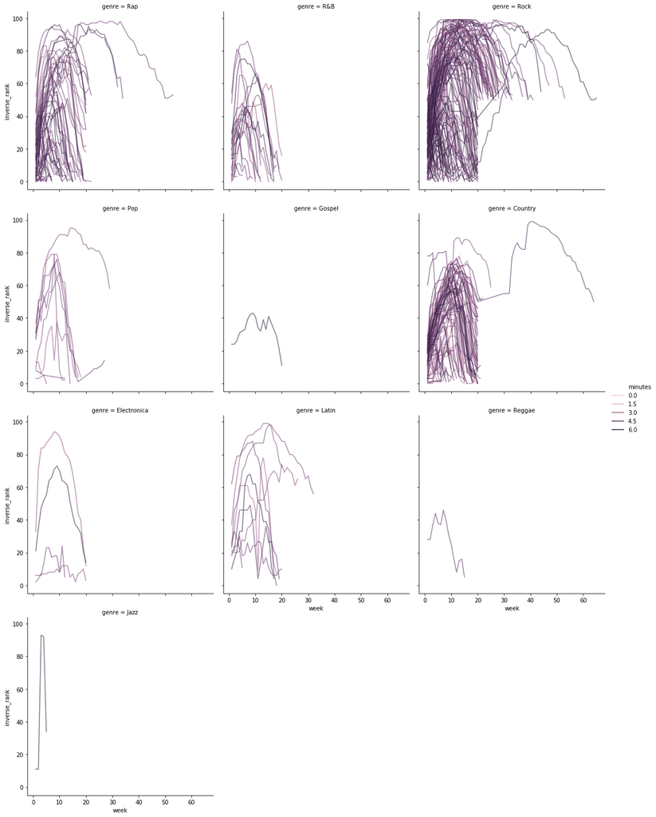

```python
plot = sns.relplot(
    x="week",
    y="inverse_rank",
    units="track",
    col="genre",
    kind="line",
    hue="minutes",
    hue_norm=plt.Normalize(1, 5),
    alpha=0.6,
    estimator=None,
    col_wrap=3,
    data=billboard
)

plot
```

The reason this was not too complicated to make was that we could refer directly to a week variable in the x-axis. This variable didn't exist before we tided the data!

A final consideration. Notice how the data are sort of redundant: We repeat the same information about the songs, each week they appear on the billboard.

```python
billboard
```

|  | year | artist.inverted | track | time | genre | date.entered | date.peaked | week | rank | entered | peaked | minutes | inverse_rank |
| --- | --- | --- | --- | --- | --- | --- | --- | --- | --- | --- | --- | --- | --- |
| 246 | 2000 | 2 Pac | Baby Don't Cry (Keep Ya Head Up II) | 4:22 | Rap | 2000-02-26 | 2000-03-11 | 1 | 87 | 2000-02-26 | 2000-03-11 | 4.366667 | 13 |
| 563 | 2000 | 2 Pac | Baby Don't Cry (Keep Ya Head Up II) | 4:22 | Rap | 2000-02-26 | 2000-03-11 | 2 | 82 | 2000-02-26 | 2000-03-11 | 4.366667 | 18 |
| 880 | 2000 | 2 Pac | Baby Don't Cry (Keep Ya Head Up II) | 4:22 | Rap | 2000-02-26 | 2000-03-11 | 3 | 72 | 2000-02-26 | 2000-03-11 | 4.366667 | 28 |
| 1197 | 2000 | 2 Pac | Baby Don't Cry (Keep Ya Head Up II) | 4:22 | Rap | 2000-02-26 | 2000-03-11 | 4 | 77 | 2000-02-26 | 2000-03-11 | 4.366667 | 23 |
| 1514 | 2000 | 2 Pac | Baby Don't Cry (Keep Ya Head Up II) | 4:22 | Rap | 2000-02-26 | 2000-03-11 | 5 | 87 | 2000-02-26 | 2000-03-11 | 4.366667 | 13 |
| 1831 | 2000 | 2 Pac | Baby Don't Cry (Keep Ya Head Up II) | 4:22 | Rap | 2000-02-26 | 2000-03-11 | 6 | 94 | 2000-02-26 | 2000-03-11 | 4.366667 | 6 |
| 2148 | 2000 | 2 Pac | Baby Don't Cry (Keep Ya Head Up II) | 4:22 | Rap | 2000-02-26 | 2000-03-11 | 7 | 99 | 2000-02-26 | 2000-03-11 | 4.366667 | 1 |
| 287 | 2000 | 2Ge+her | The Hardest Part Of Breaking Up (Is Getting Ba... | 3:15 | R&B | 2000-09-02 | 2000-09-09 | 1 | 91 | 2000-09-02 | 2000-09-09 | 3.250000 | 9 |
| 604 | 2000 | 2Ge+her | The Hardest Part Of Breaking Up (Is Getting Ba... | 3:15 | R&B | 2000-09-02 | 2000-09-09 | 2 | 87 | 2000-09-02 | 2000-09-09 | 3.250000 | 13 |
| 921 | 2000 | 2Ge+her | The Hardest Part Of Breaking Up (Is Getting Ba... | 3:15 | R&B | 2000-09-02 | 2000-09-09 | 3 | 92 | 2000-09-02 | 2000-09-09 | 3.250000 | 8 |
| 24 | 2000 | 3 Doors Down | Kryptonite | 3:53 | Rock | 2000-04-08 | 2000-11-11 | 1 | 81 | 2000-04-08 | 2000-11-11 | 3.883333 | 19 |
| 341 | 2000 | 3 Doors Down | Kryptonite | 3:53 | Rock | 2000-04-08 | 2000-11-11 | 2 | 70 | 2000-04-08 | 2000-11-11 | 3.883333 | 30 |
| 658 | 2000 | 3 Doors Down | Kryptonite | 3:53 | Rock | 2000-04-08 | 2000-11-11 | 3 | 68 | 2000-04-08 | 2000-11-11 | 3.883333 | 32 |
| 975 | 2000 | 3 Doors Down | Kryptonite | 3:53 | Rock | 2000-04-08 | 2000-11-11 | 4 | 67 | 2000-04-08 | 2000-11-11 | 3.883333 | 33 |
| 1292 | 2000 | 3 Doors Down | Kryptonite | 3:53 | Rock | 2000-04-08 | 2000-11-11 | 5 | 66 | 2000-04-08 | 2000-11-11 | 3.883333 | 34 |
| 1609 | 2000 | 3 Doors Down | Kryptonite | 3:53 | Rock | 2000-04-08 | 2000-11-11 | 6 | 57 | 2000-04-08 | 2000-11-11 | 3.883333 | 43 |
| 1926 | 2000 | 3 Doors Down | Kryptonite | 3:53 | Rock | 2000-04-08 | 2000-11-11 | 7 | 54 | 2000-04-08 | 2000-11-11 | 3.883333 | 46 |
| 2243 | 2000 | 3 Doors Down | Kryptonite | 3:53 | Rock | 2000-04-08 | 2000-11-11 | 8 | 53 | 2000-04-08 | 2000-11-11 | 3.883333 | 47 |
| 2560 | 2000 | 3 Doors Down | Kryptonite | 3:53 | Rock | 2000-04-08 | 2000-11-11 | 9 | 51 | 2000-04-08 | 2000-11-11 | 3.883333 | 49 |
| 2877 | 2000 | 3 Doors Down | Kryptonite | 3:53 | Rock | 2000-04-08 | 2000-11-11 | 10 | 51 | 2000-04-08 | 2000-11-11 | 3.883333 | 49 |
| 3194 | 2000 | 3 Doors Down | Kryptonite | 3:53 | Rock | 2000-04-08 | 2000-11-11 | 11 | 51 | 2000-04-08 | 2000-11-11 | 3.883333 | 49 |
| 3511 | 2000 | 3 Doors Down | Kryptonite | 3:53 | Rock | 2000-04-08 | 2000-11-11 | 12 | 51 | 2000-04-08 | 2000-11-11 | 3.883333 | 49 |
| 3828 | 2000 | 3 Doors Down | Kryptonite | 3:53 | Rock | 2000-04-08 | 2000-11-11 | 13 | 47 | 2000-04-08 | 2000-11-11 | 3.883333 | 53 |
| 4145 | 2000 | 3 Doors Down | Kryptonite | 3:53 | Rock | 2000-04-08 | 2000-11-11 | 14 | 44 | 2000-04-08 | 2000-11-11 | 3.883333 | 56 |
| 4462 | 2000 | 3 Doors Down | Kryptonite | 3:53 | Rock | 2000-04-08 | 2000-11-11 | 15 | 38 | 2000-04-08 | 2000-11-11 | 3.883333 | 62 |
| 4779 | 2000 | 3 Doors Down | Kryptonite | 3:53 | Rock | 2000-04-08 | 2000-11-11 | 16 | 28 | 2000-04-08 | 2000-11-11 | 3.883333 | 72 |
| 5096 | 2000 | 3 Doors Down | Kryptonite | 3:53 | Rock | 2000-04-08 | 2000-11-11 | 17 | 22 | 2000-04-08 | 2000-11-11 | 3.883333 | 78 |
| 5413 | 2000 | 3 Doors Down | Kryptonite | 3:53 | Rock | 2000-04-08 | 2000-11-11 | 18 | 18 | 2000-04-08 | 2000-11-11 | 3.883333 | 82 |
| 5730 | 2000 | 3 Doors Down | Kryptonite | 3:53 | Rock | 2000-04-08 | 2000-11-11 | 19 | 18 | 2000-04-08 | 2000-11-11 | 3.883333 | 82 |
| 6047 | 2000 | 3 Doors Down | Kryptonite | 3:53 | Rock | 2000-04-08 | 2000-11-11 | 20 | 14 | 2000-04-08 | 2000-11-11 | 3.883333 | 86 |
| ... | ... | ... | ... | ... | ... | ... | ... | ... | ... | ... | ... | ... | ... |
| 2868 | 2000 | matchbox twenty | Bent | 4:12 | Rock | 2000-04-29 | 2000-07-22 | 10 | 12 | 2000-04-29 | 2000-07-22 | 4.200000 | 88 |
| 3185 | 2000 | matchbox twenty | Bent | 4:12 | Rock | 2000-04-29 | 2000-07-22 | 11 | 8 | 2000-04-29 | 2000-07-22 | 4.200000 | 92 |
| 3502 | 2000 | matchbox twenty | Bent | 4:12 | Rock | 2000-04-29 | 2000-07-22 | 12 | 6 | 2000-04-29 | 2000-07-22 | 4.200000 | 94 |
| 3819 | 2000 | matchbox twenty | Bent | 4:12 | Rock | 2000-04-29 | 2000-07-22 | 13 | 1 | 2000-04-29 | 2000-07-22 | 4.200000 | 99 |
| 4136 | 2000 | matchbox twenty | Bent | 4:12 | Rock | 2000-04-29 | 2000-07-22 | 14 | 2 | 2000-04-29 | 2000-07-22 | 4.200000 | 98 |
| 4453 | 2000 | matchbox twenty | Bent | 4:12 | Rock | 2000-04-29 | 2000-07-22 | 15 | 3 | 2000-04-29 | 2000-07-22 | 4.200000 | 97 |
| 4770 | 2000 | matchbox twenty | Bent | 4:12 | Rock | 2000-04-29 | 2000-07-22 | 16 | 2 | 2000-04-29 | 2000-07-22 | 4.200000 | 98 |
| 5087 | 2000 | matchbox twenty | Bent | 4:12 | Rock | 2000-04-29 | 2000-07-22 | 17 | 2 | 2000-04-29 | 2000-07-22 | 4.200000 | 98 |
| 5404 | 2000 | matchbox twenty | Bent | 4:12 | Rock | 2000-04-29 | 2000-07-22 | 18 | 3 | 2000-04-29 | 2000-07-22 | 4.200000 | 97 |
| 5721 | 2000 | matchbox twenty | Bent | 4:12 | Rock | 2000-04-29 | 2000-07-22 | 19 | 4 | 2000-04-29 | 2000-07-22 | 4.200000 | 96 |
| 6038 | 2000 | matchbox twenty | Bent | 4:12 | Rock | 2000-04-29 | 2000-07-22 | 20 | 5 | 2000-04-29 | 2000-07-22 | 4.200000 | 95 |
| 6355 | 2000 | matchbox twenty | Bent | 4:12 | Rock | 2000-04-29 | 2000-07-22 | 21 | 4 | 2000-04-29 | 2000-07-22 | 4.200000 | 96 |
| 6672 | 2000 | matchbox twenty | Bent | 4:12 | Rock | 2000-04-29 | 2000-07-22 | 22 | 4 | 2000-04-29 | 2000-07-22 | 4.200000 | 96 |
| 6989 | 2000 | matchbox twenty | Bent | 4:12 | Rock | 2000-04-29 | 2000-07-22 | 23 | 6 | 2000-04-29 | 2000-07-22 | 4.200000 | 94 |
| 7306 | 2000 | matchbox twenty | Bent | 4:12 | Rock | 2000-04-29 | 2000-07-22 | 24 | 9 | 2000-04-29 | 2000-07-22 | 4.200000 | 91 |
| 7623 | 2000 | matchbox twenty | Bent | 4:12 | Rock | 2000-04-29 | 2000-07-22 | 25 | 12 | 2000-04-29 | 2000-07-22 | 4.200000 | 88 |
| 7940 | 2000 | matchbox twenty | Bent | 4:12 | Rock | 2000-04-29 | 2000-07-22 | 26 | 13 | 2000-04-29 | 2000-07-22 | 4.200000 | 87 |
| 8257 | 2000 | matchbox twenty | Bent | 4:12 | Rock | 2000-04-29 | 2000-07-22 | 27 | 19 | 2000-04-29 | 2000-07-22 | 4.200000 | 81 |
| 8574 | 2000 | matchbox twenty | Bent | 4:12 | Rock | 2000-04-29 | 2000-07-22 | 28 | 20 | 2000-04-29 | 2000-07-22 | 4.200000 | 80 |
| 8891 | 2000 | matchbox twenty | Bent | 4:12 | Rock | 2000-04-29 | 2000-07-22 | 29 | 20 | 2000-04-29 | 2000-07-22 | 4.200000 | 80 |
| 9208 | 2000 | matchbox twenty | Bent | 4:12 | Rock | 2000-04-29 | 2000-07-22 | 30 | 24 | 2000-04-29 | 2000-07-22 | 4.200000 | 76 |
| 9525 | 2000 | matchbox twenty | Bent | 4:12 | Rock | 2000-04-29 | 2000-07-22 | 31 | 29 | 2000-04-29 | 2000-07-22 | 4.200000 | 71 |
| 9842 | 2000 | matchbox twenty | Bent | 4:12 | Rock | 2000-04-29 | 2000-07-22 | 32 | 28 | 2000-04-29 | 2000-07-22 | 4.200000 | 72 |
| 10159 | 2000 | matchbox twenty | Bent | 4:12 | Rock | 2000-04-29 | 2000-07-22 | 33 | 27 | 2000-04-29 | 2000-07-22 | 4.200000 | 73 |
| 10476 | 2000 | matchbox twenty | Bent | 4:12 | Rock | 2000-04-29 | 2000-07-22 | 34 | 30 | 2000-04-29 | 2000-07-22 | 4.200000 | 70 |
| 10793 | 2000 | matchbox twenty | Bent | 4:12 | Rock | 2000-04-29 | 2000-07-22 | 35 | 33 | 2000-04-29 | 2000-07-22 | 4.200000 | 67 |
| 11110 | 2000 | matchbox twenty | Bent | 4:12 | Rock | 2000-04-29 | 2000-07-22 | 36 | 37 | 2000-04-29 | 2000-07-22 | 4.200000 | 63 |
| 11427 | 2000 | matchbox twenty | Bent | 4:12 | Rock | 2000-04-29 | 2000-07-22 | 37 | 38 | 2000-04-29 | 2000-07-22 | 4.200000 | 62 |
| 11744 | 2000 | matchbox twenty | Bent | 4:12 | Rock | 2000-04-29 | 2000-07-22 | 38 | 38 | 2000-04-29 | 2000-07-22 | 4.200000 | 62 |
| 12061 | 2000 | matchbox twenty | Bent | 4:12 | Rock | 2000-04-29 | 2000-07-22 | 39 | 48 | 2000-04-29 | 2000-07-22 | 4.200000 | 52 |

5307 rows × 13 columns

This is another instance of the "sample ambiguity" problem. One way to resolve this is to split the data into two tables (which can be joined as needed),

- A *songs* table, giving attributes about each song
- A *ranks* table, providing the rankings of different songs across weeks.

First, let's make the songs table. The idea is to select the variables about songs that are constant across all weeks.

```python
song_cols = billboard.columns[:7]
songs = (billboard[song_cols].drop_duplicates()
          .sort_values(["genre", "artist.inverted", "track"])
          .assign(song_id=lambda df: df.reset_index().index))
songs.set_index("song_id").reset_index() # moves song_id to the front
```

|  | song_id | year | artist.inverted | track | time | genre | date.entered | date.peaked |
| --- | --- | --- | --- | --- | --- | --- | --- | --- |
| 0 | 0 | 2000 | Adkins, Trace | More | 3:05 | Country | 2000-04-29 | 2000-06-17 |
| 1 | 1 | 2000 | Allan, Gary | Smoke Rings In The Dark | 4:18 | Country | 2000-01-22 | 2000-02-05 |
| 2 | 2 | 2000 | Black, Clint | Been There | 5:28 | Country | 2000-02-19 | 2000-04-15 |
| 3 | 3 | 2000 | Brock, Chad | A Country Boy Can Survive | 3:54 | Country | 2000-01-01 | 2000-01-08 |
| 4 | 4 | 2000 | Brock, Chad | Yes! | 3:22 | Country | 2000-04-08 | 2000-07-01 |
| 5 | 5 | 2000 | Brooks & Dunn | You'll Always Be Loved By Me | 2:58 | Country | 2000-06-10 | 2000-09-09 |
| 6 | 6 | 2000 | Brooks, Garth | Do What You Gotta Do | 2:56 | Country | 2000-02-19 | 2000-03-18 |
| 7 | 7 | 2000 | Byrd, Tracy | Put Your Hand In Mine | 4:30 | Country | 2000-01-29 | 2000-02-12 |
| 8 | 8 | 2000 | Cagle, Chris | My Love Goes On And On | 3:02 | Country | 2000-10-21 | 2000-12-02 |
| 9 | 9 | 2000 | Chesney, Kenny | I Lost It | 3:54 | Country | 2000-10-21 | 2000-12-23 |
| 10 | 10 | 2000 | Chesney, Kenny | What I Need To Do | 4:05 | Country | 2000-04-01 | 2000-06-10 |
| 11 | 11 | 2000 | Clark Family Experience | Meanwhile Back At The Ranch | 2:56 | Country | 2000-11-18 | 2000-12-16 |
| 12 | 12 | 2000 | Clark, Terri | A Little Gasoline | 3:07 | Country | 2000-12-16 | 2000-12-16 |
| 13 | 13 | 2000 | Cyrus, Billy Ray | You Won't Be Lonely Now | 3:45 | Country | 2000-09-23 | 2000-11-11 |
| 14 | 14 | 2000 | Davidson, Clay | Unconditional | 3:56 | Country | 2000-03-25 | 2000-06-17 |
| 15 | 15 | 2000 | Diffie, Joe | It's Always Somethin' | 2:55 | Country | 2000-08-12 | 2000-09-16 |
| 16 | 16 | 2000 | Diffie, Joe | The Quittin' Kind | 3:23 | Country | 2000-01-01 | 2000-01-22 |
| 17 | 17 | 2000 | Dixie Chicks, The | Cold Day In July | 5:12 | Country | 2000-06-24 | 2000-08-05 |
| 18 | 18 | 2000 | Dixie Chicks, The | Cowboy Take Me Away | 4:51 | Country | 1999-11-27 | 2000-01-29 |
| 19 | 19 | 2000 | Dixie Chicks, The | Goodbye Earl | 4:19 | Country | 2000-03-18 | 2000-05-06 |
| 20 | 20 | 2000 | Dixie Chicks, The | Without You | 3:32 | Country | 2000-10-07 | 2000-12-23 |
| 21 | 21 | 2000 | Evans, Sara | Born To Fly | 5:36 | Country | 2000-10-21 | 2000-12-30 |
| 22 | 22 | 2000 | Gill, Vince | Feels Like Love | 4:13 | Country | 2000-09-02 | 2000-11-18 |
| 23 | 23 | 2000 | Gilman, Billy | One Voice | 4:07 | Country | 2000-06-17 | 2000-09-02 |
| 24 | 24 | 2000 | Griggs, Andy | She's More | 3:19 | Country | 2000-03-11 | 2000-06-10 |
| 25 | 25 | 2000 | Hanson | This Time Around | 4:14 | Country | 2000-04-22 | 2000-05-06 |
| 26 | 26 | 2000 | Hart, Beth | L.A. Song | 3:47 | Country | 1999-11-27 | 2000-01-15 |
| 27 | 27 | 2000 | Heatherly, Eric | Flowers On The Wall | 3:16 | Country | 2000-04-29 | 2000-08-12 |
| 28 | 28 | 2000 | Herndon, Ty | No Mercy | 4:43 | Country | 2000-03-18 | 2000-05-06 |
| 29 | 29 | 2000 | Jackson, Alan | It Must Be Love | 2:53 | Country | 2000-06-24 | 2000-09-02 |
| ... | ... | ... | ... | ... | ... | ... | ... | ... |
| 287 | 287 | 2000 | Smash Mouth | Then The Morning Comes | 3:04 | Rock | 1999-10-30 | 2000-01-29 |
| 288 | 288 | 2000 | Sonique | It Feels So Good | 3:48 | Rock | 2000-01-22 | 2000-04-22 |
| 289 | 289 | 2000 | SoulDecision | Faded | 3:25 | Rock | 2000-07-08 | 2000-09-09 |
| 290 | 290 | 2000 | Spears, Britney | From The Bottom Of My Broken Heart | 4:30 | Rock | 2000-01-29 | 2000-02-26 |
| 291 | 291 | 2000 | Spears, Britney | Lucky | 3:23 | Rock | 2000-08-12 | 2000-09-09 |
| 292 | 292 | 2000 | Spears, Britney | Oops!.. I Did It Again | 3:30 | Rock | 2000-04-22 | 2000-06-10 |
| 293 | 293 | 2000 | Spencer, Tracie | Still In My Heart | 4:11 | Rock | 2000-03-04 | 2000-03-11 |
| 294 | 294 | 2000 | Sting | Desert Rose | 3:52 | Rock | 2000-05-13 | 2000-08-26 |
| 295 | 295 | 2000 | Stone Temple Pilots | Sour Girl | 4:16 | Rock | 2000-07-08 | 2000-07-29 |
| 296 | 296 | 2000 | Sugar Ray | Falls Apart | 4:15 | Rock | 2000-01-15 | 2000-02-19 |
| 297 | 297 | 2000 | TLC | Dear Lie | 4:36 | Rock | 2000-02-12 | 2000-03-04 |
| 298 | 298 | 2000 | Tamar | If You Don't Wanna Love Me | 4:02 | Rock | 2000-03-25 | 2000-04-15 |
| 299 | 299 | 2000 | Tamia | Can't Go For That | 3:38 | Rock | 2000-09-16 | 2000-09-30 |
| 300 | 300 | 2000 | Third Eye Blind | Deep Inside Of You | 4:10 | Rock | 2000-09-02 | 2000-10-07 |
| 301 | 301 | 2000 | Third Eye Blind | Never Let You Go | 3:57 | Rock | 2000-01-22 | 2000-04-01 |
| 302 | 302 | 2000 | Thomas, Carl | Emotional | 4:31 | Rock | 2000-11-25 | 2000-12-30 |
| 303 | 303 | 2000 | Thomas, Carl | I Wish | 3:50 | Rock | 2000-03-25 | 2000-05-13 |
| 304 | 304 | 2000 | Thomas, Carl | Summer Rain | 4:57 | Rock | 2000-09-23 | 2000-10-14 |
| 305 | 305 | 2000 | Train | Meet Virginia | 3:55 | Rock | 1999-10-09 | 2000-01-22 |
| 306 | 306 | 2000 | Tuesday | I Know | 4:06 | Rock | 2000-12-30 | 2000-12-30 |
| 307 | 307 | 2000 | Usher | Pop Ya Collar | 3:36 | Rock | 2000-11-04 | 2000-11-18 |
| 308 | 308 | 2000 | Vertical Horizon | Everything You Want | 4:01 | Rock | 2000-01-22 | 2000-07-15 |
| 309 | 309 | 2000 | Vertical Horizon | You're A God | 3:45 | Rock | 2000-08-26 | 2000-11-04 |
| 310 | 310 | 2000 | Vitamin C | Graduation (Friends Forever) | 4:23 | Rock | 2000-04-15 | 2000-06-10 |
| 311 | 311 | 2000 | Vitamin C | The Itch | 3:30 | Rock | 2000-12-02 | 2000-12-16 |
| 312 | 312 | 2000 | Wallflowers, The | Sleepwalker | 3:29 | Rock | 2000-10-28 | 2000-10-28 |
| 313 | 313 | 2000 | Westlife | Swear It Again | 4:07 | Rock | 2000-04-01 | 2000-07-01 |
| 314 | 314 | 2000 | Williams, Robbie | Angels | 3:56 | Rock | 1999-11-20 | 2000-01-22 |
| 315 | 315 | 2000 | Zombie Nation | Kernkraft 400 | 3:30 | Rock | 2000-09-02 | 2000-09-02 |
| 316 | 316 | 2000 | matchbox twenty | Bent | 4:12 | Rock | 2000-04-29 | 2000-07-22 |

317 rows × 8 columns

```python
join_cols = ["year", "artist.inverted", "track"]
ranks = pd.merge(billboard, songs, on=join_cols)
ranks
```

|  | year | artist.inverted | track | time_x | genre_x | date.entered_x | date.peaked_x | week | rank | entered | peaked | minutes | inverse_rank | time_y | genre_y | date.entered_y | date.peaked_y | song_id |
| --- | --- | --- | --- | --- | --- | --- | --- | --- | --- | --- | --- | --- | --- | --- | --- | --- | --- | --- |
| 0 | 2000 | 2 Pac | Baby Don't Cry (Keep Ya Head Up II) | 4:22 | Rap | 2000-02-26 | 2000-03-11 | 1 | 87 | 2000-02-26 | 2000-03-11 | 4.366667 | 13 | 4:22 | Rap | 2000-02-26 | 2000-03-11 | 121 |
| 1 | 2000 | 2 Pac | Baby Don't Cry (Keep Ya Head Up II) | 4:22 | Rap | 2000-02-26 | 2000-03-11 | 2 | 82 | 2000-02-26 | 2000-03-11 | 4.366667 | 18 | 4:22 | Rap | 2000-02-26 | 2000-03-11 | 121 |
| 2 | 2000 | 2 Pac | Baby Don't Cry (Keep Ya Head Up II) | 4:22 | Rap | 2000-02-26 | 2000-03-11 | 3 | 72 | 2000-02-26 | 2000-03-11 | 4.366667 | 28 | 4:22 | Rap | 2000-02-26 | 2000-03-11 | 121 |
| 3 | 2000 | 2 Pac | Baby Don't Cry (Keep Ya Head Up II) | 4:22 | Rap | 2000-02-26 | 2000-03-11 | 4 | 77 | 2000-02-26 | 2000-03-11 | 4.366667 | 23 | 4:22 | Rap | 2000-02-26 | 2000-03-11 | 121 |
| 4 | 2000 | 2 Pac | Baby Don't Cry (Keep Ya Head Up II) | 4:22 | Rap | 2000-02-26 | 2000-03-11 | 5 | 87 | 2000-02-26 | 2000-03-11 | 4.366667 | 13 | 4:22 | Rap | 2000-02-26 | 2000-03-11 | 121 |
| 5 | 2000 | 2 Pac | Baby Don't Cry (Keep Ya Head Up II) | 4:22 | Rap | 2000-02-26 | 2000-03-11 | 6 | 94 | 2000-02-26 | 2000-03-11 | 4.366667 | 6 | 4:22 | Rap | 2000-02-26 | 2000-03-11 | 121 |
| 6 | 2000 | 2 Pac | Baby Don't Cry (Keep Ya Head Up II) | 4:22 | Rap | 2000-02-26 | 2000-03-11 | 7 | 99 | 2000-02-26 | 2000-03-11 | 4.366667 | 1 | 4:22 | Rap | 2000-02-26 | 2000-03-11 | 121 |
| 7 | 2000 | 2Ge+her | The Hardest Part Of Breaking Up (Is Getting Ba... | 3:15 | R&B | 2000-09-02 | 2000-09-09 | 1 | 91 | 2000-09-02 | 2000-09-09 | 3.250000 | 9 | 3:15 | R&B | 2000-09-02 | 2000-09-09 | 98 |
| 8 | 2000 | 2Ge+her | The Hardest Part Of Breaking Up (Is Getting Ba... | 3:15 | R&B | 2000-09-02 | 2000-09-09 | 2 | 87 | 2000-09-02 | 2000-09-09 | 3.250000 | 13 | 3:15 | R&B | 2000-09-02 | 2000-09-09 | 98 |
| 9 | 2000 | 2Ge+her | The Hardest Part Of Breaking Up (Is Getting Ba... | 3:15 | R&B | 2000-09-02 | 2000-09-09 | 3 | 92 | 2000-09-02 | 2000-09-09 | 3.250000 | 8 | 3:15 | R&B | 2000-09-02 | 2000-09-09 | 98 |
| 10 | 2000 | 3 Doors Down | Kryptonite | 3:53 | Rock | 2000-04-08 | 2000-11-11 | 1 | 81 | 2000-04-08 | 2000-11-11 | 3.883333 | 19 | 3:53 | Rock | 2000-04-08 | 2000-11-11 | 180 |
| 11 | 2000 | 3 Doors Down | Kryptonite | 3:53 | Rock | 2000-04-08 | 2000-11-11 | 2 | 70 | 2000-04-08 | 2000-11-11 | 3.883333 | 30 | 3:53 | Rock | 2000-04-08 | 2000-11-11 | 180 |
| 12 | 2000 | 3 Doors Down | Kryptonite | 3:53 | Rock | 2000-04-08 | 2000-11-11 | 3 | 68 | 2000-04-08 | 2000-11-11 | 3.883333 | 32 | 3:53 | Rock | 2000-04-08 | 2000-11-11 | 180 |
| 13 | 2000 | 3 Doors Down | Kryptonite | 3:53 | Rock | 2000-04-08 | 2000-11-11 | 4 | 67 | 2000-04-08 | 2000-11-11 | 3.883333 | 33 | 3:53 | Rock | 2000-04-08 | 2000-11-11 | 180 |
| 14 | 2000 | 3 Doors Down | Kryptonite | 3:53 | Rock | 2000-04-08 | 2000-11-11 | 5 | 66 | 2000-04-08 | 2000-11-11 | 3.883333 | 34 | 3:53 | Rock | 2000-04-08 | 2000-11-11 | 180 |
| 15 | 2000 | 3 Doors Down | Kryptonite | 3:53 | Rock | 2000-04-08 | 2000-11-11 | 6 | 57 | 2000-04-08 | 2000-11-11 | 3.883333 | 43 | 3:53 | Rock | 2000-04-08 | 2000-11-11 | 180 |
| 16 | 2000 | 3 Doors Down | Kryptonite | 3:53 | Rock | 2000-04-08 | 2000-11-11 | 7 | 54 | 2000-04-08 | 2000-11-11 | 3.883333 | 46 | 3:53 | Rock | 2000-04-08 | 2000-11-11 | 180 |
| 17 | 2000 | 3 Doors Down | Kryptonite | 3:53 | Rock | 2000-04-08 | 2000-11-11 | 8 | 53 | 2000-04-08 | 2000-11-11 | 3.883333 | 47 | 3:53 | Rock | 2000-04-08 | 2000-11-11 | 180 |
| 18 | 2000 | 3 Doors Down | Kryptonite | 3:53 | Rock | 2000-04-08 | 2000-11-11 | 9 | 51 | 2000-04-08 | 2000-11-11 | 3.883333 | 49 | 3:53 | Rock | 2000-04-08 | 2000-11-11 | 180 |
| 19 | 2000 | 3 Doors Down | Kryptonite | 3:53 | Rock | 2000-04-08 | 2000-11-11 | 10 | 51 | 2000-04-08 | 2000-11-11 | 3.883333 | 49 | 3:53 | Rock | 2000-04-08 | 2000-11-11 | 180 |
| 20 | 2000 | 3 Doors Down | Kryptonite | 3:53 | Rock | 2000-04-08 | 2000-11-11 | 11 | 51 | 2000-04-08 | 2000-11-11 | 3.883333 | 49 | 3:53 | Rock | 2000-04-08 | 2000-11-11 | 180 |
| 21 | 2000 | 3 Doors Down | Kryptonite | 3:53 | Rock | 2000-04-08 | 2000-11-11 | 12 | 51 | 2000-04-08 | 2000-11-11 | 3.883333 | 49 | 3:53 | Rock | 2000-04-08 | 2000-11-11 | 180 |
| 22 | 2000 | 3 Doors Down | Kryptonite | 3:53 | Rock | 2000-04-08 | 2000-11-11 | 13 | 47 | 2000-04-08 | 2000-11-11 | 3.883333 | 53 | 3:53 | Rock | 2000-04-08 | 2000-11-11 | 180 |
| 23 | 2000 | 3 Doors Down | Kryptonite | 3:53 | Rock | 2000-04-08 | 2000-11-11 | 14 | 44 | 2000-04-08 | 2000-11-11 | 3.883333 | 56 | 3:53 | Rock | 2000-04-08 | 2000-11-11 | 180 |
| 24 | 2000 | 3 Doors Down | Kryptonite | 3:53 | Rock | 2000-04-08 | 2000-11-11 | 15 | 38 | 2000-04-08 | 2000-11-11 | 3.883333 | 62 | 3:53 | Rock | 2000-04-08 | 2000-11-11 | 180 |
| 25 | 2000 | 3 Doors Down | Kryptonite | 3:53 | Rock | 2000-04-08 | 2000-11-11 | 16 | 28 | 2000-04-08 | 2000-11-11 | 3.883333 | 72 | 3:53 | Rock | 2000-04-08 | 2000-11-11 | 180 |
| 26 | 2000 | 3 Doors Down | Kryptonite | 3:53 | Rock | 2000-04-08 | 2000-11-11 | 17 | 22 | 2000-04-08 | 2000-11-11 | 3.883333 | 78 | 3:53 | Rock | 2000-04-08 | 2000-11-11 | 180 |
| 27 | 2000 | 3 Doors Down | Kryptonite | 3:53 | Rock | 2000-04-08 | 2000-11-11 | 18 | 18 | 2000-04-08 | 2000-11-11 | 3.883333 | 82 | 3:53 | Rock | 2000-04-08 | 2000-11-11 | 180 |
| 28 | 2000 | 3 Doors Down | Kryptonite | 3:53 | Rock | 2000-04-08 | 2000-11-11 | 19 | 18 | 2000-04-08 | 2000-11-11 | 3.883333 | 82 | 3:53 | Rock | 2000-04-08 | 2000-11-11 | 180 |
| 29 | 2000 | 3 Doors Down | Kryptonite | 3:53 | Rock | 2000-04-08 | 2000-11-11 | 20 | 14 | 2000-04-08 | 2000-11-11 | 3.883333 | 86 | 3:53 | Rock | 2000-04-08 | 2000-11-11 | 180 |
| ... | ... | ... | ... | ... | ... | ... | ... | ... | ... | ... | ... | ... | ... | ... | ... | ... | ... | ... |
| 5277 | 2000 | matchbox twenty | Bent | 4:12 | Rock | 2000-04-29 | 2000-07-22 | 10 | 12 | 2000-04-29 | 2000-07-22 | 4.200000 | 88 | 4:12 | Rock | 2000-04-29 | 2000-07-22 | 316 |
| 5278 | 2000 | matchbox twenty | Bent | 4:12 | Rock | 2000-04-29 | 2000-07-22 | 11 | 8 | 2000-04-29 | 2000-07-22 | 4.200000 | 92 | 4:12 | Rock | 2000-04-29 | 2000-07-22 | 316 |
| 5279 | 2000 | matchbox twenty | Bent | 4:12 | Rock | 2000-04-29 | 2000-07-22 | 12 | 6 | 2000-04-29 | 2000-07-22 | 4.200000 | 94 | 4:12 | Rock | 2000-04-29 | 2000-07-22 | 316 |
| 5280 | 2000 | matchbox twenty | Bent | 4:12 | Rock | 2000-04-29 | 2000-07-22 | 13 | 1 | 2000-04-29 | 2000-07-22 | 4.200000 | 99 | 4:12 | Rock | 2000-04-29 | 2000-07-22 | 316 |
| 5281 | 2000 | matchbox twenty | Bent | 4:12 | Rock | 2000-04-29 | 2000-07-22 | 14 | 2 | 2000-04-29 | 2000-07-22 | 4.200000 | 98 | 4:12 | Rock | 2000-04-29 | 2000-07-22 | 316 |
| 5282 | 2000 | matchbox twenty | Bent | 4:12 | Rock | 2000-04-29 | 2000-07-22 | 15 | 3 | 2000-04-29 | 2000-07-22 | 4.200000 | 97 | 4:12 | Rock | 2000-04-29 | 2000-07-22 | 316 |
| 5283 | 2000 | matchbox twenty | Bent | 4:12 | Rock | 2000-04-29 | 2000-07-22 | 16 | 2 | 2000-04-29 | 2000-07-22 | 4.200000 | 98 | 4:12 | Rock | 2000-04-29 | 2000-07-22 | 316 |
| 5284 | 2000 | matchbox twenty | Bent | 4:12 | Rock | 2000-04-29 | 2000-07-22 | 17 | 2 | 2000-04-29 | 2000-07-22 | 4.200000 | 98 | 4:12 | Rock | 2000-04-29 | 2000-07-22 | 316 |
| 5285 | 2000 | matchbox twenty | Bent | 4:12 | Rock | 2000-04-29 | 2000-07-22 | 18 | 3 | 2000-04-29 | 2000-07-22 | 4.200000 | 97 | 4:12 | Rock | 2000-04-29 | 2000-07-22 | 316 |
| 5286 | 2000 | matchbox twenty | Bent | 4:12 | Rock | 2000-04-29 | 2000-07-22 | 19 | 4 | 2000-04-29 | 2000-07-22 | 4.200000 | 96 | 4:12 | Rock | 2000-04-29 | 2000-07-22 | 316 |
| 5287 | 2000 | matchbox twenty | Bent | 4:12 | Rock | 2000-04-29 | 2000-07-22 | 20 | 5 | 2000-04-29 | 2000-07-22 | 4.200000 | 95 | 4:12 | Rock | 2000-04-29 | 2000-07-22 | 316 |
| 5288 | 2000 | matchbox twenty | Bent | 4:12 | Rock | 2000-04-29 | 2000-07-22 | 21 | 4 | 2000-04-29 | 2000-07-22 | 4.200000 | 96 | 4:12 | Rock | 2000-04-29 | 2000-07-22 | 316 |
| 5289 | 2000 | matchbox twenty | Bent | 4:12 | Rock | 2000-04-29 | 2000-07-22 | 22 | 4 | 2000-04-29 | 2000-07-22 | 4.200000 | 96 | 4:12 | Rock | 2000-04-29 | 2000-07-22 | 316 |
| 5290 | 2000 | matchbox twenty | Bent | 4:12 | Rock | 2000-04-29 | 2000-07-22 | 23 | 6 | 2000-04-29 | 2000-07-22 | 4.200000 | 94 | 4:12 | Rock | 2000-04-29 | 2000-07-22 | 316 |
| 5291 | 2000 | matchbox twenty | Bent | 4:12 | Rock | 2000-04-29 | 2000-07-22 | 24 | 9 | 2000-04-29 | 2000-07-22 | 4.200000 | 91 | 4:12 | Rock | 2000-04-29 | 2000-07-22 | 316 |
| 5292 | 2000 | matchbox twenty | Bent | 4:12 | Rock | 2000-04-29 | 2000-07-22 | 25 | 12 | 2000-04-29 | 2000-07-22 | 4.200000 | 88 | 4:12 | Rock | 2000-04-29 | 2000-07-22 | 316 |
| 5293 | 2000 | matchbox twenty | Bent | 4:12 | Rock | 2000-04-29 | 2000-07-22 | 26 | 13 | 2000-04-29 | 2000-07-22 | 4.200000 | 87 | 4:12 | Rock | 2000-04-29 | 2000-07-22 | 316 |
| 5294 | 2000 | matchbox twenty | Bent | 4:12 | Rock | 2000-04-29 | 2000-07-22 | 27 | 19 | 2000-04-29 | 2000-07-22 | 4.200000 | 81 | 4:12 | Rock | 2000-04-29 | 2000-07-22 | 316 |
| 5295 | 2000 | matchbox twenty | Bent | 4:12 | Rock | 2000-04-29 | 2000-07-22 | 28 | 20 | 2000-04-29 | 2000-07-22 | 4.200000 | 80 | 4:12 | Rock | 2000-04-29 | 2000-07-22 | 316 |
| 5296 | 2000 | matchbox twenty | Bent | 4:12 | Rock | 2000-04-29 | 2000-07-22 | 29 | 20 | 2000-04-29 | 2000-07-22 | 4.200000 | 80 | 4:12 | Rock | 2000-04-29 | 2000-07-22 | 316 |
| 5297 | 2000 | matchbox twenty | Bent | 4:12 | Rock | 2000-04-29 | 2000-07-22 | 30 | 24 | 2000-04-29 | 2000-07-22 | 4.200000 | 76 | 4:12 | Rock | 2000-04-29 | 2000-07-22 | 316 |
| 5298 | 2000 | matchbox twenty | Bent | 4:12 | Rock | 2000-04-29 | 2000-07-22 | 31 | 29 | 2000-04-29 | 2000-07-22 | 4.200000 | 71 | 4:12 | Rock | 2000-04-29 | 2000-07-22 | 316 |
| 5299 | 2000 | matchbox twenty | Bent | 4:12 | Rock | 2000-04-29 | 2000-07-22 | 32 | 28 | 2000-04-29 | 2000-07-22 | 4.200000 | 72 | 4:12 | Rock | 2000-04-29 | 2000-07-22 | 316 |
| 5300 | 2000 | matchbox twenty | Bent | 4:12 | Rock | 2000-04-29 | 2000-07-22 | 33 | 27 | 2000-04-29 | 2000-07-22 | 4.200000 | 73 | 4:12 | Rock | 2000-04-29 | 2000-07-22 | 316 |
| 5301 | 2000 | matchbox twenty | Bent | 4:12 | Rock | 2000-04-29 | 2000-07-22 | 34 | 30 | 2000-04-29 | 2000-07-22 | 4.200000 | 70 | 4:12 | Rock | 2000-04-29 | 2000-07-22 | 316 |
| 5302 | 2000 | matchbox twenty | Bent | 4:12 | Rock | 2000-04-29 | 2000-07-22 | 35 | 33 | 2000-04-29 | 2000-07-22 | 4.200000 | 67 | 4:12 | Rock | 2000-04-29 | 2000-07-22 | 316 |
| 5303 | 2000 | matchbox twenty | Bent | 4:12 | Rock | 2000-04-29 | 2000-07-22 | 36 | 37 | 2000-04-29 | 2000-07-22 | 4.200000 | 63 | 4:12 | Rock | 2000-04-29 | 2000-07-22 | 316 |
| 5304 | 2000 | matchbox twenty | Bent | 4:12 | Rock | 2000-04-29 | 2000-07-22 | 37 | 38 | 2000-04-29 | 2000-07-22 | 4.200000 | 62 | 4:12 | Rock | 2000-04-29 | 2000-07-22 | 316 |
| 5305 | 2000 | matchbox twenty | Bent | 4:12 | Rock | 2000-04-29 | 2000-07-22 | 38 | 38 | 2000-04-29 | 2000-07-22 | 4.200000 | 62 | 4:12 | Rock | 2000-04-29 | 2000-07-22 | 316 |
| 5306 | 2000 | matchbox twenty | Bent | 4:12 | Rock | 2000-04-29 | 2000-07-22 | 39 | 48 | 2000-04-29 | 2000-07-22 | 4.200000 | 52 | 4:12 | Rock | 2000-04-29 | 2000-07-22 | 316 |

5307 rows × 18 columns

```python
ranks[["song_id", "week", "rank"]]
```

|  | song_id | week | rank |
| --- | --- | --- | --- |
| 0 | 121 | 1 | 87 |
| 1 | 121 | 2 | 82 |
| 2 | 121 | 3 | 72 |
| 3 | 121 | 4 | 77 |
| 4 | 121 | 5 | 87 |
| 5 | 121 | 6 | 94 |
| 6 | 121 | 7 | 99 |
| 7 | 98 | 1 | 91 |
| 8 | 98 | 2 | 87 |
| 9 | 98 | 3 | 92 |
| 10 | 180 | 1 | 81 |
| 11 | 180 | 2 | 70 |
| 12 | 180 | 3 | 68 |
| 13 | 180 | 4 | 67 |
| 14 | 180 | 5 | 66 |
| 15 | 180 | 6 | 57 |
| 16 | 180 | 7 | 54 |
| 17 | 180 | 8 | 53 |
| 18 | 180 | 9 | 51 |
| 19 | 180 | 10 | 51 |
| 20 | 180 | 11 | 51 |
| 21 | 180 | 12 | 51 |
| 22 | 180 | 13 | 47 |
| 23 | 180 | 14 | 44 |
| 24 | 180 | 15 | 38 |
| 25 | 180 | 16 | 28 |
| 26 | 180 | 17 | 22 |
| 27 | 180 | 18 | 18 |
| 28 | 180 | 19 | 18 |
| 29 | 180 | 20 | 14 |
| ... | ... | ... | ... |
| 5277 | 316 | 10 | 12 |
| 5278 | 316 | 11 | 8 |
| 5279 | 316 | 12 | 6 |
| 5280 | 316 | 13 | 1 |
| 5281 | 316 | 14 | 2 |
| 5282 | 316 | 15 | 3 |
| 5283 | 316 | 16 | 2 |
| 5284 | 316 | 17 | 2 |
| 5285 | 316 | 18 | 3 |
| 5286 | 316 | 19 | 4 |
| 5287 | 316 | 20 | 5 |
| 5288 | 316 | 21 | 4 |
| 5289 | 316 | 22 | 4 |
| 5290 | 316 | 23 | 6 |
| 5291 | 316 | 24 | 9 |
| 5292 | 316 | 25 | 12 |
| 5293 | 316 | 26 | 13 |
| 5294 | 316 | 27 | 19 |
| 5295 | 316 | 28 | 20 |
| 5296 | 316 | 29 | 20 |
| 5297 | 316 | 30 | 24 |
| 5298 | 316 | 31 | 29 |
| 5299 | 316 | 32 | 28 |
| 5300 | 316 | 33 | 27 |
| 5301 | 316 | 34 | 30 |
| 5302 | 316 | 35 | 33 |
| 5303 | 316 | 36 | 37 |
| 5304 | 316 | 37 | 38 |
| 5305 | 316 | 38 | 38 |
| 5306 | 316 | 39 | 48 |

5307 rows × 3 columns